# Introduzione_a_scikit-learn

## Introduzione a Scikit-Learn (sklearn)

Questo notebook illustra alcune delle funzioni più utili della fantastica libreria Scikit-Learn.

Di cosa parleremo:

```python
# Let's listify the contents
what_were_covering = [
'0. Un flusso di lavoro Scikit-Learn end-to-end',
 '1. Preparazione dei dati',
 '2. Scelta dello stimatore/algoritmo giusto per i nostri problemi',
 '3. Adattamento del modello/algoritmo e utilizzo per fare previsioni sui nostri dati',
 '4. Valutazione di un modello',
 '5. Migliorare un modello',
 '6. Salvataggio e caricamento di un modello addestrato',
 '7. Messa insieme del tutto!']
```

```python
what_were_covering
```

```
['0. Un flusso di lavoro Scikit-Learn end-to-end',
 '1. Preparazione dei dati',
 '2. Scelta dello stimatore/algoritmo giusto per i nostri problemi',
 '3. Adattamento del modello/algoritmo e utilizzo per fare previsioni sui nostri dati',
 '4. Valutazione di un modello',
 '5. Migliorare un modello',
 '6. Salvataggio e caricamento di un modello addestrato',
 '7. Messa insieme del tutto!']
```

```python
# Standard imports
import numpy as np
import pandas as pd
import matplotlib.pyplot as plt
from matplotlib.image import imread
!pip install seaborn
```

## 0. Un flusso di lavoro Scikit-Learn end-to-end

```python
# 1. Preparazione dei dati
import pandas as pd
heart_disease = pd.read_csv("dati/heart-disease.csv")
heart_disease
```

|  | age | sex | cp | trestbps | chol | fbs | restecg | thalach | exang | oldpeak | slope | ca | thal | target |
| --- | --- | --- | --- | --- | --- | --- | --- | --- | --- | --- | --- | --- | --- | --- |
| 0 | 63 | 1 | 3 | 145 | 233 | 1 | 0 | 150 | 0 | 2.3 | 0 | 0 | 1 | 1 |
| 1 | 37 | 1 | 2 | 130 | 250 | 0 | 1 | 187 | 0 | 3.5 | 0 | 0 | 2 | 1 |
| 2 | 41 | 0 | 1 | 130 | 204 | 0 | 0 | 172 | 0 | 1.4 | 2 | 0 | 2 | 1 |
| 3 | 56 | 1 | 1 | 120 | 236 | 0 | 1 | 178 | 0 | 0.8 | 2 | 0 | 2 | 1 |
| 4 | 57 | 0 | 0 | 120 | 354 | 0 | 1 | 163 | 1 | 0.6 | 2 | 0 | 2 | 1 |
| ... | ... | ... | ... | ... | ... | ... | ... | ... | ... | ... | ... | ... | ... | ... |
| 298 | 57 | 0 | 0 | 140 | 241 | 0 | 1 | 123 | 1 | 0.2 | 1 | 0 | 3 | 0 |
| 299 | 45 | 1 | 3 | 110 | 264 | 0 | 1 | 132 | 0 | 1.2 | 1 | 0 | 3 | 0 |
| 300 | 68 | 1 | 0 | 144 | 193 | 1 | 1 | 141 | 0 | 3.4 | 1 | 2 | 3 | 0 |
| 301 | 57 | 1 | 0 | 130 | 131 | 0 | 1 | 115 | 1 | 1.2 | 1 | 1 | 3 | 0 |
| 302 | 57 | 0 | 1 | 130 | 236 | 0 | 0 | 174 | 0 | 0.0 | 1 | 1 | 2 | 0 |

303 rows × 14 columns

```python
# Create X (features matrix)
X = heart_disease.drop("target", axis=1)

# Create y (labels)
y = heart_disease["target"]
```

```python
# 2. Scelta dello stimatore/algoritmo giusto per i nostri problemi
from sklearn.ensemble import RandomForestClassifier
clf = RandomForestClassifier(n_estimators=100)

# We'll keep the default hyperparameters
clf.get_params()
```

```
{'bootstrap': True,
 'ccp_alpha': 0.0,
 'class_weight': None,
 'criterion': 'gini',
 'max_depth': None,
 'max_features': 'sqrt',
 'max_leaf_nodes': None,
 'max_samples': None,
 'min_impurity_decrease': 0.0,
 'min_samples_leaf': 1,
 'min_samples_split': 2,
 'min_weight_fraction_leaf': 0.0,
 'monotonic_cst': None,
 'n_estimators': 100,
 'n_jobs': None,
 'oob_score': False,
 'random_state': None,
 'verbose': 0,
 'warm_start': False}
```

```python
# 3. Adattamento del modello/algoritmo e utilizzo per fare previsioni sui nostri dati

from sklearn.model_selection import train_test_split

X_train, X_test, y_train, y_test = train_test_split(X, y, test_size=0.2)
```

```python
clf.fit(X_train, y_train);
```

```python
X_train
```

|  | age | sex | cp | trestbps | chol | fbs | restecg | thalach | exang | oldpeak | slope | ca | thal |
| --- | --- | --- | --- | --- | --- | --- | --- | --- | --- | --- | --- | --- | --- |
| 118 | 46 | 0 | 1 | 105 | 204 | 0 | 1 | 172 | 0 | 0.0 | 2 | 0 | 2 |
| 188 | 50 | 1 | 2 | 140 | 233 | 0 | 1 | 163 | 0 | 0.6 | 1 | 1 | 3 |
| 180 | 55 | 1 | 0 | 132 | 353 | 0 | 1 | 132 | 1 | 1.2 | 1 | 1 | 3 |
| 202 | 58 | 1 | 0 | 150 | 270 | 0 | 0 | 111 | 1 | 0.8 | 2 | 0 | 3 |
| 79 | 58 | 1 | 2 | 105 | 240 | 0 | 0 | 154 | 1 | 0.6 | 1 | 0 | 3 |
| ... | ... | ... | ... | ... | ... | ... | ... | ... | ... | ... | ... | ... | ... |
| 187 | 54 | 1 | 0 | 124 | 266 | 0 | 0 | 109 | 1 | 2.2 | 1 | 1 | 3 |
| 192 | 54 | 1 | 0 | 120 | 188 | 0 | 1 | 113 | 0 | 1.4 | 1 | 1 | 3 |
| 243 | 57 | 1 | 0 | 152 | 274 | 0 | 1 | 88 | 1 | 1.2 | 1 | 1 | 3 |
| 166 | 67 | 1 | 0 | 120 | 229 | 0 | 0 | 129 | 1 | 2.6 | 1 | 2 | 3 |
| 77 | 59 | 1 | 1 | 140 | 221 | 0 | 1 | 164 | 1 | 0.0 | 2 | 0 | 2 |

242 rows × 13 columns

```python
# make a prediction
y_label = clf.predict(np.array([0, 2, 3, 4]))
```

[output not shown]

[output cut: 8 more lines]

[output not shown]

```python
# ho corretto errore
y_preds = clf.predict(X_test)
y_preds
```

```python
y_test
```

```python
 ## 4. Valutazione di un modello
# mi dice che l' addestramento e arrivato al 100%
clf.score(X_train, y_train)
```

[output not shown]

```python
# qui mi indica 75% precisione
clf.score(X_test, y_test)
```

[output not shown]

```python
from sklearn.metrics import classification_report, confusion_matrix, accuracy_score

print(classification_report(y_test, y_preds))
```

```python
confusion_matrix(y_test, y_preds)
```

```python
#75%
accuracy_score(y_test, y_preds)
```

[output not shown]

```python
# 5. Migliorare un modello
# Try different amount of n_estimators
np.random.seed(42)
for i in range(10, 100, 10):
    print(f"Trying model with {i} estimators...")
    clf = RandomForestClassifier(n_estimators=i).fit(X_train, y_train)
    print(f"Model accuracy on test set: {clf.score(X_test, y_test) * 100:.2f}%")
    print("")
```

```python
# 6. Salvataggio e caricamento di un modello addestrato
import pickle

pickle.dump(clf, open("random_forst_model_1.pkl", "wb"))  #wb sta per write binary
```

```python
# dopo il salvataggio lo ricaricato
loaded_model = pickle.load(open("random_forst_model_1.pkl", "rb"))  # tb sta per read binary
loaded_model.score(X_test, y_test)
```

## 1. Prepariamo i nostri dati per essere utilizzati con l'apprendimento automatico

Dobbiamo fare tre cose principali:

1. Dividere i dati in caratteristiche ed etichette (solitamente X e y)
2. Riempire (chiamato anche imputare) o ignorare i valori mancanti
3. Convertire i valori non numerici in valori numerici (chiamato anche codifica delle caratteristiche)

```python
heart_disease.head()
```

```python
X = heart_disease.drop("target", axis=1)
X.head()
```

```python
y = heart_disease["target"]
y.head()
```

```python
# Divido i dati in set di allenamento e li testo
from sklearn.model_selection import train_test_split
X_train, X_test, y_train, y_test = train_test_split(X,
                                                    y,
                                                    test_size=0.3)
```

```python
X_train.shape, X_test.shape, y_train.shape, y_test.shape
```

```python
X.shape
```

```python
len(heart_disease)
```

```python
X.shape[0] * 0.8
```

```python
242 + 61
```

# Prima di creare un modello di machine learning, per evitare che a fine giornata abbiamo dati inutili

1. Pulizia dei dati: rimuovere dati o valori mancanti o etichette mancanti, questo non ci permette di avere il modello giusto di machine, rimuoviamo qualcosa di mancante e aggiungiamo una media, per esempio il prezzo medio di una casa, oppure un dato falso lo rimuoviamo.
2. Trasformazione dei Dati: trasformero in RGB i colori, informazioni, immagini ecc in numeri perche i computer capiascono solo 0 e 1.
3. Ridurre i Dati: Non vogliamo piu dati possibile perche, piu dati vuol dire consumare piu tempo,CPU, e con meno dati posso ottenere lo stesso risultato e risparmiando anche denaro che e un obbietivo delle grandi aziende

## 1.1 Assicurati che sia tutto numerico

```python
car_sales = pd.read_csv("dati/car-sales-extended.csv")
car_sales.head()
```

|  | Make | Colour | Odometer (KM) | Doors | Price |
| --- | --- | --- | --- | --- | --- |
| 0 | Honda | White | 35431 | 4 | 15323 |
| 1 | BMW | Blue | 192714 | 5 | 19943 |
| 2 | Honda | White | 84714 | 4 | 28343 |
| 3 | Toyota | White | 154365 | 4 | 13434 |
| 4 | Nissan | Blue | 181577 | 3 | 14043 |

```python
car_sales["Doors"].value_counts()
```

```
Doors
4    856
5     79
3     65
Name: count, dtype: int64
```

```python
len(car_sales)
```

```
1000
```

```python
car_sales.dtypes
```

```
Make             object
Colour           object
Odometer (KM)     int64
Doors             int64
Price             int64
dtype: object
```

```python
# Divido X/y
X = car_sales.drop("Price", axis=1)
y = car_sales["Price"]

# Split into training and test
X_train, X_test, y_train, y_test = train_test_split(X,
                                                   y,
                                                   test_size=0.2)
```

```python
# costruisco modello di machine learning
from sklearn.ensemble import RandomForestRegressor

model = RandomForestRegressor()
model.fit(X_train, y_train)
model.score(X_test, y_test)
```

[output not shown]

[output cut: 23 more lines]

[output not shown]

```python
## i modelli di machinelearning non supportano le stringhe 'Toyota' e li devo trasformare in numeri
```

```python
X.head()
```

|  | Make | Colour | Odometer (KM) | Doors |
| --- | --- | --- | --- | --- |
| 0 | Honda | White | 35431 | 4 |
| 1 | BMW | Blue | 192714 | 5 |
| 2 | Honda | White | 84714 | 4 |
| 3 | Toyota | White | 154365 | 4 |
| 4 | Nissan | Blue | 181577 | 3 |

```python
X
```

|  | Make | Colour | Odometer (KM) | Doors |
| --- | --- | --- | --- | --- |
| 0 | Honda | White | 35431 | 4 |
| 1 | BMW | Blue | 192714 | 5 |
| 2 | Honda | White | 84714 | 4 |
| 3 | Toyota | White | 154365 | 4 |
| 4 | Nissan | Blue | 181577 | 3 |
| ... | ... | ... | ... | ... |
| 995 | Toyota | Black | 35820 | 4 |
| 996 | Nissan | White | 155144 | 3 |
| 997 | Nissan | Blue | 66604 | 4 |
| 998 | Honda | White | 215883 | 4 |
| 999 | Toyota | Blue | 248360 | 4 |

1000 rows × 4 columns

```python
# Trasformare le categorie in numeri
from sklearn.preprocessing import OneHotEncoder
from sklearn.compose import ColumnTransformer

categorical_features = ["Make", "Colour", "Doors"]
one_hot = OneHotEncoder()
transformer = ColumnTransformer([("one_hot",
                                   one_hot,
                                   categorical_features)],
                                   remainder="passthrough")

transformed_X = transformer.fit_transform(X)
transformed_X
```

```
array([[0.00000e+00, 1.00000e+00, 0.00000e+00, ..., 1.00000e+00,
        0.00000e+00, 3.54310e+04],
       [1.00000e+00, 0.00000e+00, 0.00000e+00, ..., 0.00000e+00,
        1.00000e+00, 1.92714e+05],
       [0.00000e+00, 1.00000e+00, 0.00000e+00, ..., 1.00000e+00,
        0.00000e+00, 8.47140e+04],
       ...,
       [0.00000e+00, 0.00000e+00, 1.00000e+00, ..., 1.00000e+00,
        0.00000e+00, 6.66040e+04],
       [0.00000e+00, 1.00000e+00, 0.00000e+00, ..., 1.00000e+00,
        0.00000e+00, 2.15883e+05],
       [0.00000e+00, 0.00000e+00, 0.00000e+00, ..., 1.00000e+00,
        0.00000e+00, 2.48360e+05]])
```

```python
X
```

|  | Make | Colour | Odometer (KM) | Doors |
| --- | --- | --- | --- | --- |
| 0 | Honda | White | 35431 | 4 |
| 1 | BMW | Blue | 192714 | 5 |
| 2 | Honda | White | 84714 | 4 |
| 3 | Toyota | White | 154365 | 4 |
| 4 | Nissan | Blue | 181577 | 3 |
| ... | ... | ... | ... | ... |
| 995 | Toyota | Black | 35820 | 4 |
| 996 | Nissan | White | 155144 | 3 |
| 997 | Nissan | Blue | 66604 | 4 |
| 998 | Honda | White | 215883 | 4 |
| 999 | Toyota | Blue | 248360 | 4 |

1000 rows × 4 columns

```python
pd.DataFrame(transformed_X)
```

|  | 0 | 1 | 2 | 3 | 4 | 5 | 6 | 7 | 8 | 9 | 10 | 11 | 12 |
| --- | --- | --- | --- | --- | --- | --- | --- | --- | --- | --- | --- | --- | --- |
| 0 | 0.0 | 1.0 | 0.0 | 0.0 | 0.0 | 0.0 | 0.0 | 0.0 | 1.0 | 0.0 | 1.0 | 0.0 | 35431.0 |
| 1 | 1.0 | 0.0 | 0.0 | 0.0 | 0.0 | 1.0 | 0.0 | 0.0 | 0.0 | 0.0 | 0.0 | 1.0 | 192714.0 |
| 2 | 0.0 | 1.0 | 0.0 | 0.0 | 0.0 | 0.0 | 0.0 | 0.0 | 1.0 | 0.0 | 1.0 | 0.0 | 84714.0 |
| 3 | 0.0 | 0.0 | 0.0 | 1.0 | 0.0 | 0.0 | 0.0 | 0.0 | 1.0 | 0.0 | 1.0 | 0.0 | 154365.0 |
| 4 | 0.0 | 0.0 | 1.0 | 0.0 | 0.0 | 1.0 | 0.0 | 0.0 | 0.0 | 1.0 | 0.0 | 0.0 | 181577.0 |
| ... | ... | ... | ... | ... | ... | ... | ... | ... | ... | ... | ... | ... | ... |
| 995 | 0.0 | 0.0 | 0.0 | 1.0 | 1.0 | 0.0 | 0.0 | 0.0 | 0.0 | 0.0 | 1.0 | 0.0 | 35820.0 |
| 996 | 0.0 | 0.0 | 1.0 | 0.0 | 0.0 | 0.0 | 0.0 | 0.0 | 1.0 | 1.0 | 0.0 | 0.0 | 155144.0 |
| 997 | 0.0 | 0.0 | 1.0 | 0.0 | 0.0 | 1.0 | 0.0 | 0.0 | 0.0 | 0.0 | 1.0 | 0.0 | 66604.0 |
| 998 | 0.0 | 1.0 | 0.0 | 0.0 | 0.0 | 0.0 | 0.0 | 0.0 | 1.0 | 0.0 | 1.0 | 0.0 | 215883.0 |
| 999 | 0.0 | 0.0 | 0.0 | 1.0 | 0.0 | 1.0 | 0.0 | 0.0 | 0.0 | 0.0 | 1.0 | 0.0 | 248360.0 |

1000 rows × 13 columns

```python
# Another way to do it with pd.dummies...
dummies = pd.get_dummies(car_sales[["Make", "Colour", "Doors"]])
dummies
```

|  | Doors | Make_BMW | Make_Honda | Make_Nissan | Make_Toyota | Colour_Black | Colour_Blue | Colour_Green | Colour_Red | Colour_White |
| --- | --- | --- | --- | --- | --- | --- | --- | --- | --- | --- |
| 0 | 4 | False | True | False | False | False | False | False | False | True |
| 1 | 5 | True | False | False | False | False | True | False | False | False |
| 2 | 4 | False | True | False | False | False | False | False | False | True |
| 3 | 4 | False | False | False | True | False | False | False | False | True |
| 4 | 3 | False | False | True | False | False | True | False | False | False |
| ... | ... | ... | ... | ... | ... | ... | ... | ... | ... | ... |
| 995 | 4 | False | False | False | True | True | False | False | False | False |
| 996 | 3 | False | False | True | False | False | False | False | False | True |
| 997 | 4 | False | False | True | False | False | True | False | False | False |
| 998 | 4 | False | True | False | False | False | False | False | False | True |
| 999 | 4 | False | False | False | True | False | True | False | False | False |

1000 rows × 10 columns

```python
# riprovo il modello
np.random.seed(42)
X_train, X_test, y_train, y_test = train_test_split(transformed_X,
                                                    y,
                                                    test_size=0.2)

model.fit(X_train, y_train)
```

```
RandomForestRegressor()
```

```python
X.head()
```

|  | Make | Colour | Odometer (KM) | Doors |
| --- | --- | --- | --- | --- |
| 0 | Honda | White | 35431 | 4 |
| 1 | BMW | Blue | 192714 | 5 |
| 2 | Honda | White | 84714 | 4 |
| 3 | Toyota | White | 154365 | 4 |
| 4 | Nissan | Blue | 181577 | 3 |

```python
model.score(X_test, y_test)
```

```
0.3235867221569877
```

## 1.2 Cosa succede se ci sono valori mancanti?

1. Riempili con un valore (noto anche come imputazione).
2. Rimuovere completamente i campioni con dati mancanti.

```python
## Importo il csv che ha dei dati mancanti
car_sales_missing = pd.read_csv("dati/car-sales-extended-missing-data.csv")
car_sales_missing.head()
```

|  | Make | Colour | Odometer (KM) | Doors | Price |
| --- | --- | --- | --- | --- | --- |
| 0 | Honda | White | 35431.0 | 4.0 | 15323.0 |
| 1 | BMW | Blue | 192714.0 | 5.0 | 19943.0 |
| 2 | Honda | White | 84714.0 | 4.0 | 28343.0 |
| 3 | Toyota | White | 154365.0 | 4.0 | 13434.0 |
| 4 | Nissan | Blue | 181577.0 | 3.0 | 14043.0 |

```python
car_sales_missing.tail()
```

|  | Make | Colour | Odometer (KM) | Doors | Price |
| --- | --- | --- | --- | --- | --- |
| 995 | Toyota | Black | 35820.0 | 4.0 | 32042.0 |
| 996 | NaN | White | 155144.0 | 3.0 | 5716.0 |
| 997 | Nissan | Blue | 66604.0 | 4.0 | 31570.0 |
| 998 | Honda | White | 215883.0 | 4.0 | 4001.0 |
| 999 | Toyota | Blue | 248360.0 | 4.0 | 12732.0 |

```python
# Modo veloce per vedere se e qwuanti dati mancano
# que per esempio mi dira che  in make mancano 49 valori
car_sales_missing.isna().sum()
```

```
Make             49
Colour           50
Odometer (KM)    50
Doors            50
Price            50
dtype: int64
```

```python
# Create X & y
X = car_sales_missing.drop("Price", axis=1)
y = car_sales_missing["Price"]
```

```python
# Proviamo a convertire  i nostri dati in numeri
# Turn the categories into numbers
from sklearn.preprocessing import OneHotEncoder
from sklearn.compose import ColumnTransformer

categorical_features = ["Make", "Colour", "Doors"]
one_hot = OneHotEncoder()
transformer = ColumnTransformer([("one_hot",
                                   one_hot,
                                   categorical_features)],
                                   remainder="passthrough")

transformed_X = transformer.fit_transform(X)
transformed_X
```

```
<1000x16 sparse matrix of type '<class 'numpy.float64'>'
	with 4000 stored elements in Compressed Sparse Row format>
```

```python
car_sales_missing
```

|  | Make | Colour | Odometer (KM) | Doors | Price |
| --- | --- | --- | --- | --- | --- |
| 0 | Honda | White | 35431.0 | 4.0 | 15323.0 |
| 1 | BMW | Blue | 192714.0 | 5.0 | 19943.0 |
| 2 | Honda | White | 84714.0 | 4.0 | 28343.0 |
| 3 | Toyota | White | 154365.0 | 4.0 | 13434.0 |
| 4 | Nissan | Blue | 181577.0 | 3.0 | 14043.0 |
| ... | ... | ... | ... | ... | ... |
| 995 | Toyota | Black | 35820.0 | 4.0 | 32042.0 |
| 996 | NaN | White | 155144.0 | 3.0 | 5716.0 |
| 997 | Nissan | Blue | 66604.0 | 4.0 | 31570.0 |
| 998 | Honda | White | 215883.0 | 4.0 | 4001.0 |
| 999 | Toyota | Blue | 248360.0 | 4.0 | 12732.0 |

1000 rows × 5 columns

```python
car_sales_missing["Doors"].value_counts()
```

```
Doors
4.0    811
5.0     75
3.0     64
Name: count, dtype: int64
```

## Opzione 1: Riempi i dati mancanti con Pandas

```python
## codice corso mi da problema
# Riempio la  colonna "Make"
#car_sales_missing["Make"].fillna("missing", inplace=True)
# Riempio la  colonna "Colour"
#car_sales_missing["Colour"].fillna("missing", inplace=True)
# Riempio la  colonna "Odometer (KM)"
#car_sales_missing["Odometer (KM)"].fillna(car_sales_missing["Odometer (KM)"].mean(), inplace=True)
# Riempio la  colonna "Doors"
#car_sales_missing["Doors"].fillna(4, inplace=True)



##### CODICE CORRETTO DA  ME

# Riempio la  colonna "Make"
car_sales_missing["Make"] = car_sales_missing["Make"].fillna("missing")
# Riempio la  colonna "Colour"
car_sales_missing["Colour"] = car_sales_missing["Colour"].fillna("missing")
# Riempio la  colonna "Odometer (KM)"
car_sales_missing["Odometer (KM)"] = car_sales_missing["Odometer (KM)"].fillna(car_sales_missing["Odometer (KM)"].mean())
# Riempio la  colonna "Doors"
car_sales_missing["Doors"] = car_sales_missing["Doors"].fillna(4)
```

```python
# Controliamo  ancora il nostro dataframe
car_sales_missing.isna().sum()
```

```
Make              0
Colour            0
Odometer (KM)     0
Doors             0
Price            50
dtype: int64
```

```python
# rimuovo riga prezzo  con valore vuto
car_sales_missing.dropna(inplace=True)
```

```python
car_sales_missing.isna().sum()
```

```
Make             0
Colour           0
Odometer (KM)    0
Doors            0
Price            0
dtype: int64
```

```python
len(car_sales_missing)
```

```
950
```

```python
X = car_sales_missing.drop("Price", axis=1)
y = car_sales_missing["Price"]
```

```python
# Let's try and convert our data to numbers
# Turn the categories into numbers
from sklearn.preprocessing import OneHotEncoder
from sklearn.compose import ColumnTransformer

categorical_features = ["Make", "Colour", "Doors"]
one_hot = OneHotEncoder()
transformer = ColumnTransformer([("one_hot",
                                   one_hot,
                                   categorical_features)],
                                   remainder="passthrough")

transformed_X = transformer.fit_transform(car_sales_missing)
transformed_X
```

```
array([[0.00000e+00, 1.00000e+00, 0.00000e+00, ..., 0.00000e+00,
        3.54310e+04, 1.53230e+04],
       [1.00000e+00, 0.00000e+00, 0.00000e+00, ..., 1.00000e+00,
        1.92714e+05, 1.99430e+04],
       [0.00000e+00, 1.00000e+00, 0.00000e+00, ..., 0.00000e+00,
        8.47140e+04, 2.83430e+04],
       ...,
       [0.00000e+00, 0.00000e+00, 1.00000e+00, ..., 0.00000e+00,
        6.66040e+04, 3.15700e+04],
       [0.00000e+00, 1.00000e+00, 0.00000e+00, ..., 0.00000e+00,
        2.15883e+05, 4.00100e+03],
       [0.00000e+00, 0.00000e+00, 0.00000e+00, ..., 0.00000e+00,
        2.48360e+05, 1.27320e+04]])
```

## Opzione 2: Riempimento dei dati mancanti e trasformazione dei dati categoriali con Scikit-Learn

## Nota: questa sezione è diversa dal video. Il video mostra il riempimento e la trasformazione dell'intero set di dati ( X) e, sebbene le tecniche siano corrette, è meglio riempire e trasformare separatamente i set di training e test (come mostrato nel codice seguente).

Le conclusioni principali:

- Dividi prima i tuoi dati (in treno/test)
- Riempi/trasforma separatamente il set di addestramento e i set di test.

```python
import pandas as pd

# Carica i dati
car_sales = pd.read_csv("dati/car-sales.csv")  # Assicurati che il file esista e il percorso sia corretto
```

```python
car_sales_missing = pd.read_csv("dati/car-sales-extended-missing-data.csv")
car_sales_missing.head()
```

|  | Make | Colour | Odometer (KM) | Doors | Price |
| --- | --- | --- | --- | --- | --- |
| 0 | Honda | White | 35431.0 | 4.0 | 15323.0 |
| 1 | BMW | Blue | 192714.0 | 5.0 | 19943.0 |
| 2 | Honda | White | 84714.0 | 4.0 | 28343.0 |
| 3 | Toyota | White | 154365.0 | 4.0 | 13434.0 |
| 4 | Nissan | Blue | 181577.0 | 3.0 | 14043.0 |

```python
car_sales_missing.isna().sum()
```

```
Make             49
Colour           50
Odometer (KM)    50
Doors            50
Price            50
dtype: int64
```

```python
#con il seguente codice devo rimuovere le righe senza etichette = NaN
car_sales_missing.dropna(subset=["Price"], inplace=True)
car_sales_missing.isna().sum()
```

```
Make             47
Colour           46
Odometer (KM)    48
Doors            47
Price             0
dtype: int64
```

```python
# Divido  X & y
X = car_sales_missing.drop("Price", axis=1)
y = car_sales_missing["Price"]

# Split data into train and test
np.random.seed(42)
X_train, X_test, y_train, y_test = train_test_split(X,
                                                    y,
                                                    test_size=0.2)
```

```python
# Controllo
X.isna().sum()
```

```
Make             47
Colour           46
Odometer (KM)    48
Doors            47
dtype: int64
```

```python
# riempi i valori mancanti con Scikit-Learn
from sklearn.impute import SimpleImputer
from sklearn.compose import ColumnTransformer

# Fill categorical values with 'missing' & numerical values with mean
cat_imputer = SimpleImputer(strategy="constant", fill_value="missing")
door_imputer = SimpleImputer(strategy="constant", fill_value=4)
num_imputer = SimpleImputer(strategy="mean")

# Definisco le  colonne
cat_features = ["Make", "Colour"]
door_feature = ["Doors"]
num_features = ["Odometer (KM)"]

# Creare e  importare (Qualcocsa che riempi i dati mancanti)
imputer = ColumnTransformer([
    ("cat_imputer", cat_imputer, cat_features),
    ("door_imputer", door_imputer, door_feature),
    ("num_imputer", num_imputer, num_features)
])

# Fill train and test values separately
filled_X_train = imputer.fit_transform(X_train)
filled_X_test = imputer.transform(X_test)

# Check filled X_train
filled_X_train
```

```
array([['Honda', 'White', 4.0, 71934.0],
       ['Toyota', 'Red', 4.0, 162665.0],
       ['Honda', 'White', 4.0, 42844.0],
       ...,
       ['Toyota', 'White', 4.0, 196225.0],
       ['Honda', 'Blue', 4.0, 133117.0],
       ['Honda', 'missing', 4.0, 150582.0]], dtype=object)
```

```python
# Get our transformed data array's back into DataFrame's
car_sales_filled_train = pd.DataFrame(filled_X_train,
                                      columns=["Make", "Colour", "Doors", "Odometer (KM)"])

car_sales_filled_test = pd.DataFrame(filled_X_test,
                                     columns=["Make", "Colour", "Doors", "Odometer (KM)"])

# Check missing data in training set
car_sales_filled_train.isna().sum()
```

```
Make             0
Colour           0
Doors            0
Odometer (KM)    0
dtype: int64
```

```python
# Check to see the original... still missing values
car_sales_missing.isna().sum()
```

```
Make             47
Colour           46
Odometer (KM)    48
Doors            47
Price             0
dtype: int64
```

```python
from sklearn.preprocessing import OneHotEncoder
```

```python
# Now let's one hot encode the features with the same code as before
categorical_features = ["Make", "Colour", "Doors"]
one_hot = OneHotEncoder()
transformer = ColumnTransformer([("one_hot",
                                 one_hot,
                                 categorical_features)],
                                 remainder="passthrough")

# Fill train and test values separately
transformed_X_train = transformer.fit_transform(car_sales_filled_train)
transformed_X_test = transformer.transform(car_sales_filled_test)

# Check transformed and filled X_train
transformed_X_train.toarray()
```

```
array([[0.00000e+00, 1.00000e+00, 0.00000e+00, ..., 1.00000e+00,
        0.00000e+00, 7.19340e+04],
       [0.00000e+00, 0.00000e+00, 0.00000e+00, ..., 1.00000e+00,
        0.00000e+00, 1.62665e+05],
       [0.00000e+00, 1.00000e+00, 0.00000e+00, ..., 1.00000e+00,
        0.00000e+00, 4.28440e+04],
       ...,
       [0.00000e+00, 0.00000e+00, 0.00000e+00, ..., 1.00000e+00,
        0.00000e+00, 1.96225e+05],
       [0.00000e+00, 1.00000e+00, 0.00000e+00, ..., 1.00000e+00,
        0.00000e+00, 1.33117e+05],
       [0.00000e+00, 1.00000e+00, 0.00000e+00, ..., 1.00000e+00,
        0.00000e+00, 1.50582e+05]])
```

```python
# Now we've transformed X, let's see if we can fit a model
np.random.seed(42)
from sklearn.ensemble import RandomForestRegressor

model = RandomForestRegressor()

# Make sure to use transformed (filled and one-hot encoded X data)
model.fit(transformed_X_train, y_train)
model.score(transformed_X_test, y_test)
```

```
0.21229043336119102
```

```python
# Check length of transformed data (filled and one-hot encoded)
# vs. length of original data
len(transformed_X_train.toarray())+len(transformed_X_test.toarray()), len(car-sales)
```

```
---------------------------------------------------------------------------
NameError                                 Traceback (most recent call last)
Cell In[117], line 3
      1 # Check length of transformed data (filled and one-hot encoded)
      2 # vs. length of original data
----> 3 len(transformed_X_train.toarray())+len(transformed_X_test.toarray()), len(car-sales)

NameError: name 'car' is not defined
```

### 2. Scegliere lo stimatore/algoritmo giusto per il tuo problema

Alcune cose da notare:

*Sklearn si riferisce ai modelli di apprendimento automatico e agli algoritmi come stimatori.* Problema di classificazione: prevedere una categoria (malattia cardiaca o meno) *A volte vedrai clf(abbreviazione di classificatore) utilizzato come stimatore di classificazione* Problema di regressione: prevedere un numero (prezzo di vendita di un'auto) Se stai lavorando su un problema di apprendimento automatico e stai cercando di utilizzare Sklearn e non sei sicuro di quale modello dovresti usare, fai riferimento alla mappa di apprendimento automatico di Sklearn: https://scikit-learn.org/stable/tutorial/machine_learning_map/index.html

### 2.1 Scelta di un modello di apprendimento automatico per un problema di regressione

Usiamo il set di dati California Housing - https://scikit-learn.org/stable/modules/generated/sklearn.datasets.fetch_california_housing.html

```python
# Get California Housing dataset
from sklearn.datasets import fetch_california_housing
housing = fetch_california_housing()
housing
```

```
{'data': array([[   8.3252    ,   41.        ,    6.98412698, ...,    2.55555556,
           37.88      , -122.23      ],
        [   8.3014    ,   21.        ,    6.23813708, ...,    2.10984183,
           37.86      , -122.22      ],
        [   7.2574    ,   52.        ,    8.28813559, ...,    2.80225989,
           37.85      , -122.24      ],
        ...,
        [   1.7       ,   17.        ,    5.20554273, ...,    2.3256351 ,
           39.43      , -121.22      ],
        [   1.8672    ,   18.        ,    5.32951289, ...,    2.12320917,
           39.43      , -121.32      ],
        [   2.3886    ,   16.        ,    5.25471698, ...,    2.61698113,
           39.37      , -121.24      ]]),
 'target': array([4.526, 3.585, 3.521, ..., 0.923, 0.847, 0.894]),
 'frame': None,
 'target_names': ['MedHouseVal'],
 'feature_names': ['MedInc',
  'HouseAge',
  'AveRooms',
  'AveBedrms',
  'Population',
  'AveOccup',
  'Latitude',
  'Longitude'],
 'DESCR': '.. _california_housing_dataset:\n\nCalifornia Housing dataset\n--------------------------\n\n**Data Set Characteristics:**\n\n:Number of Instances: 20640\n\n:Number of Attributes: 8 numeric, predictive attributes and the target\n\n:Attribute Information:\n    - MedInc        median income…
```

```python
housing_df = pd.DataFrame(housing["data"], columns=housing["feature_names"])
housing_df
```

|  | MedInc | HouseAge | AveRooms | AveBedrms | Population | AveOccup | Latitude | Longitude |
| --- | --- | --- | --- | --- | --- | --- | --- | --- |
| 0 | 8.3252 | 41.0 | 6.984127 | 1.023810 | 322.0 | 2.555556 | 37.88 | -122.23 |
| 1 | 8.3014 | 21.0 | 6.238137 | 0.971880 | 2401.0 | 2.109842 | 37.86 | -122.22 |
| 2 | 7.2574 | 52.0 | 8.288136 | 1.073446 | 496.0 | 2.802260 | 37.85 | -122.24 |
| 3 | 5.6431 | 52.0 | 5.817352 | 1.073059 | 558.0 | 2.547945 | 37.85 | -122.25 |
| 4 | 3.8462 | 52.0 | 6.281853 | 1.081081 | 565.0 | 2.181467 | 37.85 | -122.25 |
| ... | ... | ... | ... | ... | ... | ... | ... | ... |
| 20635 | 1.5603 | 25.0 | 5.045455 | 1.133333 | 845.0 | 2.560606 | 39.48 | -121.09 |
| 20636 | 2.5568 | 18.0 | 6.114035 | 1.315789 | 356.0 | 3.122807 | 39.49 | -121.21 |
| 20637 | 1.7000 | 17.0 | 5.205543 | 1.120092 | 1007.0 | 2.325635 | 39.43 | -121.22 |
| 20638 | 1.8672 | 18.0 | 5.329513 | 1.171920 | 741.0 | 2.123209 | 39.43 | -121.32 |
| 20639 | 2.3886 | 16.0 | 5.254717 | 1.162264 | 1387.0 | 2.616981 | 39.37 | -121.24 |

20640 rows × 8 columns

```python
housing_df["target"] = housing["target"]
housing_df.head()
```

|  | MedInc | HouseAge | AveRooms | AveBedrms | Population | AveOccup | Latitude | Longitude | target |
| --- | --- | --- | --- | --- | --- | --- | --- | --- | --- |
| 0 | 8.3252 | 41.0 | 6.984127 | 1.023810 | 322.0 | 2.555556 | 37.88 | -122.23 | 4.526 |
| 1 | 8.3014 | 21.0 | 6.238137 | 0.971880 | 2401.0 | 2.109842 | 37.86 | -122.22 | 3.585 |
| 2 | 7.2574 | 52.0 | 8.288136 | 1.073446 | 496.0 | 2.802260 | 37.85 | -122.24 | 3.521 |
| 3 | 5.6431 | 52.0 | 5.817352 | 1.073059 | 558.0 | 2.547945 | 37.85 | -122.25 | 3.413 |
| 4 | 3.8462 | 52.0 | 6.281853 | 1.081081 | 565.0 | 2.181467 | 37.85 | -122.25 | 3.422 |

```python
housing_df
```

|  | MedInc | HouseAge | AveRooms | AveBedrms | Population | AveOccup | Latitude | Longitude | target |
| --- | --- | --- | --- | --- | --- | --- | --- | --- | --- |
| 0 | 8.3252 | 41.0 | 6.984127 | 1.023810 | 322.0 | 2.555556 | 37.88 | -122.23 | 4.526 |
| 1 | 8.3014 | 21.0 | 6.238137 | 0.971880 | 2401.0 | 2.109842 | 37.86 | -122.22 | 3.585 |
| 2 | 7.2574 | 52.0 | 8.288136 | 1.073446 | 496.0 | 2.802260 | 37.85 | -122.24 | 3.521 |
| 3 | 5.6431 | 52.0 | 5.817352 | 1.073059 | 558.0 | 2.547945 | 37.85 | -122.25 | 3.413 |
| 4 | 3.8462 | 52.0 | 6.281853 | 1.081081 | 565.0 | 2.181467 | 37.85 | -122.25 | 3.422 |
| ... | ... | ... | ... | ... | ... | ... | ... | ... | ... |
| 20635 | 1.5603 | 25.0 | 5.045455 | 1.133333 | 845.0 | 2.560606 | 39.48 | -121.09 | 0.781 |
| 20636 | 2.5568 | 18.0 | 6.114035 | 1.315789 | 356.0 | 3.122807 | 39.49 | -121.21 | 0.771 |
| 20637 | 1.7000 | 17.0 | 5.205543 | 1.120092 | 1007.0 | 2.325635 | 39.43 | -121.22 | 0.923 |
| 20638 | 1.8672 | 18.0 | 5.329513 | 1.171920 | 741.0 | 2.123209 | 39.43 | -121.32 | 0.847 |
| 20639 | 2.3886 | 16.0 | 5.254717 | 1.162264 | 1387.0 | 2.616981 | 39.37 | -121.24 | 0.894 |

20640 rows × 9 columns

```python
# Algoritmo d' importazione
from sklearn.linear_model import Ridge # sto usando Ridge perche vado sulla mappa vedo che ho piu di >50 dati nono prevedo la categodia ecc

# impostazione scena casuale
np.random.seed(42)

# creo dei dati
X = housing_df.drop("target", axis=1)
y = housing_df["target"] # prezzo medio della casa a $100,000s

# divido in set di prova e test
X_train, X_test, y_train, y_test = train_test_split(X, y, test_size=0.2)

# Instantiate and fit the model (on the training set)
# istanza e addatare il imodello e (vogliamo oaddatare il modello al se e valutarlo)
model = Ridge()
model.fit(X_train, y_train)

# Check the score of the model (on the test set)
# Controliamo il punteggio del modello
model.score(X_test, y_test)
```

```
0.5758549611440127
```

E se "Ridge" non avesse funzionato o la colonna sonora non fosse stata adatta alle nostre esigenze?

Beh, potremmo sempre provare un modello diverso...

Che ne dici di provare un modello d'insieme (un insieme è una combinazione di modelli più piccoli per provare a fare previsioni migliori di quelle di un singolo modello)?

I modelli di ensemble di Sklearn possono essere trovati qui: https://scikit-learn.org/stable/modules/ensemble.html

[figure not shown]

```python
# Qui e tutto uguale pero nn uso Ridge ma  usiamo RandomForestRegressor
# Import the RandomForestRegressor model class from the ensemble module
# questo e un modello potente sia pre la classificazione e per la regressione
from sklearn.ensemble import RandomForestRegressor

# Setup random seed
np.random.seed(42)

# Create the data
X = housing_df.drop("target", axis=1)
y = housing_df["target"]

# Split into train and test sets
X_train, X_test, y_train, y_test = train_test_split(X, y, test_size=0.2)

# Create random forest model
model = RandomForestRegressor()
model.fit(X_train, y_train)

# Check the score of the model (on the test set)
model.score(X_test, y_test)
```

[output not shown]

```
---------------------------------------------------------------------------
NameError                                 Traceback (most recent call last)
Cell In[48], line 10
      7 np.random.seed(42)
      9 # Create the data
---> 10 X = housing_df.drop("target", axis=1)
     11 y = housing_df["target"]
     13 # Split into train and test sets

NameError: name 'housing_df' is not defined
```

## 2.2 Scelta di un modello di apprendimento automatico per un problema di classificazione

E dalla mappa useremo clasification Andiamo alla mappa... https://scikit-learn.org/stable/tutorial/machine_learning_map/index.html

[figure not shown]

```python
# Get the data (be sure to click "raw") - https://github.com/mrdbourke/zero-to-mastery-ml/blob/master/data/heart-disease.csv
heart_disease = pd.read_csv("https://raw.githubusercontent.com/mrdbourke/zero-to-mastery-ml/master/data/heart-disease.csv")
heart_disease.head()
```

|  | age | sex | cp | trestbps | chol | fbs | restecg | thalach | exang | oldpeak | slope | ca | thal | target |
| --- | --- | --- | --- | --- | --- | --- | --- | --- | --- | --- | --- | --- | --- | --- |
| 0 | 63 | 1 | 3 | 145 | 233 | 1 | 0 | 150 | 0 | 2.3 | 0 | 0 | 1 | 1 |
| 1 | 37 | 1 | 2 | 130 | 250 | 0 | 1 | 187 | 0 | 3.5 | 0 | 0 | 2 | 1 |
| 2 | 41 | 0 | 1 | 130 | 204 | 0 | 0 | 172 | 0 | 1.4 | 2 | 0 | 2 | 1 |
| 3 | 56 | 1 | 1 | 120 | 236 | 0 | 1 | 178 | 0 | 0.8 | 2 | 0 | 2 | 1 |
| 4 | 57 | 0 | 0 | 120 | 354 | 0 | 1 | 163 | 1 | 0.6 | 2 | 0 | 2 | 1 |

```python
len(heart_disease)
```

```
303
```

## Consulta la mappa che dice di provare LinearSVC

```python
# Import the LinearSVC estimator class
from sklearn.svm import LinearSVC

# Setup random seed
np.random.seed(42)

# Make the data
X = heart_disease.drop("target", axis=1)
y = heart_disease["target"]

# Split the data
X_train, X_test, y_train, y_test = train_test_split(X, y, test_size=0.2)

# Instantiate LinearSVC
clf = LinearSVC(max_iter=10000)
clf.fit(X_train, y_train)

# Evaluate the LinearSVC
clf.score(X_test, y_test)
```

```
0.8688524590163934
```

```python
heart_disease["target"].value_counts()
```

```
target
1    165
0    138
Name: count, dtype: int64
```

```python
# Import the RandomForestClassifier estimator class
from sklearn.ensemble import RandomForestClassifier

# Setup random seed
np.random.seed(42)

# Make the data
X = heart_disease.drop("target", axis=1)
y = heart_disease["target"]

# Split the data
X_train, X_test, y_train, y_test = train_test_split(X, y, test_size=0.2)

# Instantiate Random Forest Classifier
clf = RandomForestClassifier(n_estimators=100)
clf.fit(X_train, y_train)

# Evaluate the Random Forest Classifier
clf.score(X_test, y_test)
```

```
0.8524590163934426
```

## Curiosità:

- Se hai dati strutturati, usa metodi di insieme
- Se hai dati non strutturati, usa il deep learning o il transfer learning

```python
# in questo caso ho una tabella e quindi ho dati strutturati
heart_disease
# NOTA: invece idati non strutturati sono immagini, audio, testi
```

|  | age | sex | cp | trestbps | chol | fbs | restecg | thalach | exang | oldpeak | slope | ca | thal | target |
| --- | --- | --- | --- | --- | --- | --- | --- | --- | --- | --- | --- | --- | --- | --- |
| 0 | 63 | 1 | 3 | 145 | 233 | 1 | 0 | 150 | 0 | 2.3 | 0 | 0 | 1 | 1 |
| 1 | 37 | 1 | 2 | 130 | 250 | 0 | 1 | 187 | 0 | 3.5 | 0 | 0 | 2 | 1 |
| 2 | 41 | 0 | 1 | 130 | 204 | 0 | 0 | 172 | 0 | 1.4 | 2 | 0 | 2 | 1 |
| 3 | 56 | 1 | 1 | 120 | 236 | 0 | 1 | 178 | 0 | 0.8 | 2 | 0 | 2 | 1 |
| 4 | 57 | 0 | 0 | 120 | 354 | 0 | 1 | 163 | 1 | 0.6 | 2 | 0 | 2 | 1 |
| ... | ... | ... | ... | ... | ... | ... | ... | ... | ... | ... | ... | ... | ... | ... |
| 298 | 57 | 0 | 0 | 140 | 241 | 0 | 1 | 123 | 1 | 0.2 | 1 | 0 | 3 | 0 |
| 299 | 45 | 1 | 3 | 110 | 264 | 0 | 1 | 132 | 0 | 1.2 | 1 | 0 | 3 | 0 |
| 300 | 68 | 1 | 0 | 144 | 193 | 1 | 1 | 141 | 0 | 3.4 | 1 | 2 | 3 | 0 |
| 301 | 57 | 1 | 0 | 130 | 131 | 0 | 1 | 115 | 1 | 1.2 | 1 | 1 | 3 | 0 |
| 302 | 57 | 0 | 1 | 130 | 236 | 0 | 0 | 174 | 0 | 0.0 | 1 | 1 | 2 | 0 |

303 rows × 14 columns

## 3. Adattare il modello/algoritmo ai nostri dati e utilizzarlo per fare previsioni

### 3.1 Adattamento del modello ai dati

Nomi diversi per:

- 'X'= caratteristiche, caratteristiche variabili, dati
- 'y'= etichette, obiettivi, variabili obiettivo

```python
# Import the RandomForestClassifier estimator class
from sklearn.ensemble import RandomForestClassifier

# Setup random seed
np.random.seed(42)

# Make the data
X = heart_disease.drop("target", axis=1)
y = heart_disease["target"]

# Split the data
X_train, X_test, y_train, y_test = train_test_split(X, y, test_size=0.2)

# Instantiate Random Forest Classifier
clf = RandomForestClassifier(n_estimators=100)

# Fit the model to the data (training the machine learning model)
clf.fit(X_train, y_train)

# Evaluate the Random Forest Classifier (use the patterns the model has learned)
clf.score(X_test, y_test)
```

```
0.8524590163934426
```

```python
X.head()
```

|  | age | sex | cp | trestbps | chol | fbs | restecg | thalach | exang | oldpeak | slope | ca | thal |
| --- | --- | --- | --- | --- | --- | --- | --- | --- | --- | --- | --- | --- | --- |
| 0 | 63 | 1 | 3 | 145 | 233 | 1 | 0 | 150 | 0 | 2.3 | 0 | 0 | 1 |
| 1 | 37 | 1 | 2 | 130 | 250 | 0 | 1 | 187 | 0 | 3.5 | 0 | 0 | 2 |
| 2 | 41 | 0 | 1 | 130 | 204 | 0 | 0 | 172 | 0 | 1.4 | 2 | 0 | 2 |
| 3 | 56 | 1 | 1 | 120 | 236 | 0 | 1 | 178 | 0 | 0.8 | 2 | 0 | 2 |
| 4 | 57 | 0 | 0 | 120 | 354 | 0 | 1 | 163 | 1 | 0.6 | 2 | 0 | 2 |

```python
y.head()
```

```
0    1
1    1
2    1
3    1
4    1
Name: target, dtype: int64
```

```python
y.tail()
```

```
298    0
299    0
300    0
301    0
302    0
Name: target, dtype: int64
```

### Approfondimento del modello Random Forest

Queste risorse ti aiuteranno a capire cosa accade all'interno dei modelli Random Forest che abbiamo utilizzato.

- Foresta casuale Wikipedia
- Random Forest Wikipedia (versione semplice)
- Foreste casuali in Python di yhat

Un'implementazione e spiegazione della foresta casuale in Python di Will Koehrsen

### 3.2 Fare previsioni utilizzando un modello di apprendimento automatico

2 modi per fare previsioni:

1. 'predict()'
2. 'predict_proba()'

```python
# Use a trained model to make predictions
clf.predict(np.array([1, 7, 8, 3, 4])) # this doesn't work...


## ho provato ad aggiustatlo ma non funzione perche non funzionera
```

[output not shown]

[output cut: 8 more lines]

[output not shown]

```python
X_test.head()
```

```python
clf.predict(X_test)
```

```python
np.array(y_test)
```

```python
# Confrontiamo le previsioni con l'etichette vere per valutare il modello
y_preds = clf.predict(X_test)
np.mean(y_preds == y_test)
```

```
0.8524590163934426
```

```python
clf.score(X_test, y_test)
```

```
0.8524590163934426
```

```python
from sklearn.metrics import accuracy_score
accuracy_score(y_test, y_preds)
```

```
0.8524590163934426
```

Fai previsioni con predict_proba()- usa questa funzione se qualcuno ti chiede "qual è la probabilità che il tuo modello assegna a ciascuna previsione?"

```python
# predict_proba() ritorno di probablita di un' etichetta di classificazione
clf.predict_proba(X_test[:5])
```

```
array([[0.89, 0.11],
       [0.49, 0.51],
       [0.43, 0.57],
       [0.84, 0.16],
       [0.18, 0.82]])
```

```python
# Let's predict() on the same data...
clf.predict(X_test[:5])
```

```
array([0, 1, 1, 0, 1], dtype=int64)
```

```python
X_test[:5]
```

|  | age | sex | cp | trestbps | chol | fbs | restecg | thalach | exang | oldpeak | slope | ca | thal |
| --- | --- | --- | --- | --- | --- | --- | --- | --- | --- | --- | --- | --- | --- |
| 179 | 57 | 1 | 0 | 150 | 276 | 0 | 0 | 112 | 1 | 0.6 | 1 | 1 | 1 |
| 228 | 59 | 1 | 3 | 170 | 288 | 0 | 0 | 159 | 0 | 0.2 | 1 | 0 | 3 |
| 111 | 57 | 1 | 2 | 150 | 126 | 1 | 1 | 173 | 0 | 0.2 | 2 | 1 | 3 |
| 246 | 56 | 0 | 0 | 134 | 409 | 0 | 0 | 150 | 1 | 1.9 | 1 | 2 | 3 |
| 60 | 71 | 0 | 2 | 110 | 265 | 1 | 0 | 130 | 0 | 0.0 | 2 | 1 | 2 |

```python
heart_disease["target"].value_counts()
```

```
target
1    165
0    138
Name: count, dtype: int64
```

'predict()'può essere utilizzato anche per modelli di regressione.

```python
housing_df.head()
```

```
---------------------------------------------------------------------------
NameError                                 Traceback (most recent call last)
Cell In[67], line 1
----> 1 housing_df.head()

NameError: name 'housing_df' is not defined
```

```python
from sklearn.ensemble import RandomForestRegressor

np.random.seed(42)

# Create the data
X = housing_df.drop("target", axis=1)
y = housing_df["target"]

# Split into training and test sets
X_train, X_test, y_train, y_test = train_test_split(X, y, test_size=0.2)

# Instantiate and fit model
model = RandomForestRegressor(n_estimators=100).fit(X_train, y_train)

# Make predictions
y_preds = model.predict(X_test)
```

```
---------------------------------------------------------------------------
NameError                                 Traceback (most recent call last)
Cell In[68], line 6
      3 np.random.seed(42)
      5 # Create the data
----> 6 X = housing_df.drop("target", axis=1)
      7 y = housing_df["target"]
      9 # Split into training and test sets

NameError: name 'housing_df' is not defined
```

```python
y_preds[:10]
```

```
array([0, 1, 1, 0, 1, 1, 1, 0, 0, 1], dtype=int64)
```

```python
len(y_preds)
```

```
61
```

```python
len(y_test)
```

```
61
```

```python
np.array(y_test[:10])
```

```
array([0, 0, 1, 0, 1, 1, 1, 0, 0, 1], dtype=int64)
```

```python
# Compare the predictions to the truth
from sklearn.metrics import mean_absolute_error
mean_absolute_error(y_test, y_preds)
```

```
0.14754098360655737
```

```python
housing_df["target"]
```

```
---------------------------------------------------------------------------
NameError                                 Traceback (most recent call last)
Cell In[74], line 1
----> 1 housing_df["target"]

NameError: name 'housing_df' is not defined
```

```python
what_were_covering
```

```
['0. Un flusso di lavoro Scikit-Learn end-to-end',
 '1. Preparazione dei dati',
 '2. Scelta dello stimatore/algoritmo giusto per i nostri problemi',
 '3. Adattamento del modello/algoritmo e utilizzo per fare previsioni sui nostri dati',
 '4. Valutazione di un modello',
 '5. Migliorare un modello',
 '6. Salvataggio e caricamento di un modello addestrato',
 '7. Messa insieme del tutto!']
```

## 4. Valutazione di un modello di apprendimento automatico

Tre modi per valutare i modelli/estimatori Scikit-Learn:

1. Metodo 'score' di stima
2. Il 'scoring' parametro
3. Funzioni metriche specifiche del problema.

## 4.1 Valutazione di un modello con il 'score' metodo

```python
from sklearn.ensemble import RandomForestClassifier


np.random.seed(42)

 #creo x e y
X = heart_disease.drop("target", axis=1)
y = heart_disease["target"]


# creo allenamento/train e test
X_train, X_test, y_train, y_test = train_test_split(X, y, test_size=0.2)

# creo istanza
clf = RandomForestClassifier(n_estimators=100) # se metto 5 i riasultati non saranno perfetti potere degli algoritmi perfetti

# adatto il modello di addestramento
clf.fit(X_train, y_train)
```

```python
clf.score(X_train, y_train)
```

```python
clf.score(X_test, y_test)
```

## Facciamo lo stesso ma per la regressione

```python
from sklearn.ensemble import RandomForestRegressor

np.random.seed(42)

# Create the data
X = housing_df.drop("target", axis=1)
y = housing_df["target"]

# Split into training and test sets
X_train, X_test, y_train, y_test = train_test_split(X, y, test_size=0.2)

# Instantiate and fit model
model = RandomForestRegressor(n_estimators=100).fit(X_train, y_train)
```

```python
model.score(X_test, y_test)
```

### 4.2 Valutazione di un modello utilizzando il scoringparametro

```python
from sklearn.model_selection import cross_val_score

from sklearn.ensemble import RandomForestClassifier

np.random.seed(42)

X = heart_disease.drop("target", axis=1)
y = heart_disease["target"]

X_train, X_test, y_train, y_test = train_test_split(X, y, test_size=0.2)

clf = RandomForestClassifier(n_estimators=100)

clf.fit(X_train, y_train);
```

```python
clf.score(X_test, y_test)
```

```python
cross_val_score(clf, X, y, cv=5)
```

```python
cross_val_score(clf, X, y, cv=10)
```

```python
np.random.seed(42)

# Single training and test split score
clf_single_score = clf.score(X_test, y_test)

# Take the mean of 5-fold cross-validation score
clf_cross_val_score = np.mean(cross_val_score(clf, X, y, cv=5))

# Compare the two
clf_single_score, clf_cross_val_score
```

```python
# Default scoring parameter of classifier = mean accuracy
clf.score()
```

```python
# Scoring parameter set to None by default
cross_val_score(clf, X, y, cv=5, scoring=None)
```

### 4.2.1 Metriche di valutazione del modello di classificazione

1. Precisione
2. Area sotto la curva ROC
3. Matrice di confusione
4. Rapporto di classificazione

**Precisione**

```python
heart_disease.head()
```

|  | age | sex | cp | trestbps | chol | fbs | restecg | thalach | exang | oldpeak | slope | ca | thal | target |
| --- | --- | --- | --- | --- | --- | --- | --- | --- | --- | --- | --- | --- | --- | --- |
| 0 | 63 | 1 | 3 | 145 | 233 | 1 | 0 | 150 | 0 | 2.3 | 0 | 0 | 1 | 1 |
| 1 | 37 | 1 | 2 | 130 | 250 | 0 | 1 | 187 | 0 | 3.5 | 0 | 0 | 2 | 1 |
| 2 | 41 | 0 | 1 | 130 | 204 | 0 | 0 | 172 | 0 | 1.4 | 2 | 0 | 2 | 1 |
| 3 | 56 | 1 | 1 | 120 | 236 | 0 | 1 | 178 | 0 | 0.8 | 2 | 0 | 2 | 1 |
| 4 | 57 | 0 | 0 | 120 | 354 | 0 | 1 | 163 | 1 | 0.6 | 2 | 0 | 2 | 1 |

```python
from sklearn.model_selection import cross_val_score
from sklearn.ensemble import RandomForestClassifier

np.random.seed(42)

X = heart_disease.drop("target", axis=1)
y = heart_disease["target"]

clf = RandomForestClassifier(n_estimators=100)
cross_val_score = cross_val_score(clf, X, y, cv=5)
```

```python
np.mean(cross_val_score)
```

```
0.8248087431693989
```

```python
print(f"Heart Disease Classifier Cross-Validated Accuracy: {np.mean(cross_val_score) *100:.2f}%")
```

```
Heart Disease Classifier Cross-Validated Accuracy: 82.48%
```

**Area sotto la curva caratteristica di funzionamento del ricevitore (AUC/ROC)**

- Area sotto la curva (AUC)
- Curva ROC

Le curve ROC sono un confronto tra il tasso di veri positivi (tpr) di un modello e il tasso di falsi positivi (fpr) di un modello.

- Vero positivo = il modello prevede 1 quando la verità è 1
- Falso positivo = il modello prevede 1 quando la verità è 0
- Vero negativo = il modello prevede 0 quando la verità è 0
- Falso negativo = il modello prevede 0 quando la verità è 1

```python
# Create X_test... etc
X_train, X_test, y_train, y_test = train_test_split(X, y, test_size=0.2)
```

```python
from sklearn.metrics import roc_curve

# Fit the classifier
clf.fit(X_train, y_train)

# Make predictions with probabilities
y_probs = clf.predict_proba(X_test)

y_probs[:10], len(y_probs)
```

```
(array([[0.51, 0.49],
        [0.17, 0.83],
        [0.51, 0.49],
        [0.72, 0.28],
        [0.43, 0.57],
        [0.12, 0.88],
        [0.3 , 0.7 ],
        [0.97, 0.03],
        [0.15, 0.85],
        [0.4 , 0.6 ]]),
 61)
```

```python
y_probs_positive = y_probs[:, 1]
y_probs_positive[:10]
```

```
array([0.49, 0.83, 0.49, 0.28, 0.57, 0.88, 0.7 , 0.03, 0.85, 0.6 ])
```

```python
# Caculate fpr, tpr and thresholds
fpr, tpr, thresholds = roc_curve(y_test, y_probs_positive)

# Check the false positive rates
fpr
```

```
array([0.        , 0.03448276, 0.03448276, 0.03448276, 0.03448276,
       0.03448276, 0.03448276, 0.06896552, 0.06896552, 0.06896552,
       0.10344828, 0.10344828, 0.13793103, 0.13793103, 0.13793103,
       0.20689655, 0.20689655, 0.20689655, 0.27586207, 0.37931034,
       0.37931034, 0.48275862, 0.48275862, 0.55172414, 0.55172414,
       1.        ])
```

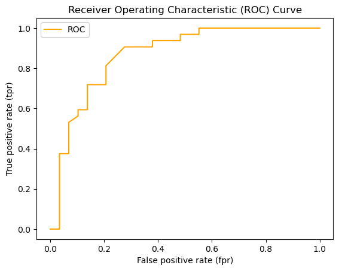

```python
# Create a function for plotting ROC curves
import matplotlib.pyplot as plt

def plot_roc_curve(fpr, tpr):
    """
    Plots a ROC curve given the false positive rate (fpr)
    and true positive rate (tpr) of a model.
    """
    # Plot roc curve
    plt.plot(fpr, tpr, color="orange", label="ROC")
    # Plot line with no predictive power (baseline)
    #plt.plot([0, 1], [0, 1], color="darkblue", linestyle="--", label="Guessing")

    # Customize the plot
    plt.xlabel("False positive rate (fpr)")
    plt.ylabel("True positive rate (tpr)")
    plt.title("Receiver Operating Characteristic (ROC) Curve")
    plt.legend()
    plt.show()

plot_roc_curve(fpr, tpr)
```

```python
from sklearn.metrics import roc_auc_score

roc_auc_score(y_test, y_probs_positive)
```

```
0.8669181034482759
```

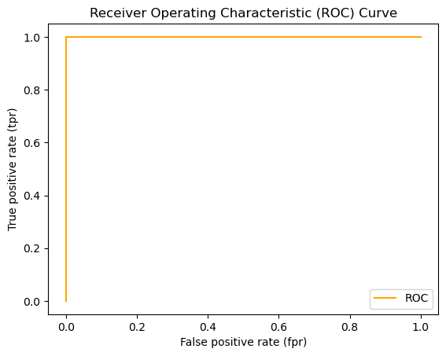

```python
# Plot perfect ROC curve and AUC score
fpr, tpr, thresholds = roc_curve(y_test, y_test)
plot_roc_curve(fpr, tpr)
```

```python
# Perfect AUC score
roc_auc_score(y_test, y_test)
```

```
1.0
```

**Matrice di confusione**

Una matrice di confusione è un modo rapido per confrontare le etichette previste da un modello e le etichette effettive che avrebbe dovuto prevedere.

In sostanza, questo ti dà un'idea di dove il modello si confonde.

```python
from sklearn.metrics import confusion_matrix

y_preds = clf.predict(X_test)

confusion_matrix(y_test, y_preds)
```

```
array([[23,  6],
       [ 6, 26]], dtype=int64)
```

```python
# Visualize confusion matrix with pd.crosstab()
pd.crosstab(y_test,
            y_preds,
            rownames=["Actual Labels"],
            colnames=["Predicted Labels"])
```

| Predicted Labels Actual Labels | 0 | 1 |
| --- | --- | --- |
| 0 | 23 | 6 |
| 1 | 6 | 26 |

```python
22 + 7 + 8 + 24
```

```
61
```

```python
len(X_test)
```

```
61
```

```python
# Come installare un pacchetto conda nell'ambiente corrente da un Jupyter Notebook
#importare \
#!conda install --yes --prefix {sys.prefix} seaborn
import seaborn as sns
sns.set(font_scale=1.5)
```

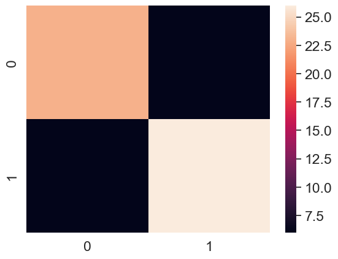

```python
# Make our confusion matrix more visual with Seaborn's heatmap()
import seaborn as sns

# Set the font scale
sns.set(font_scale=1.5)

# Create a confusion matrix
conf_mat = confusion_matrix(y_test, y_preds)

# Plot it using Seaborn
sns.heatmap(conf_mat);
```

```python
# Riprendere da video 129
```